# Project 4

Joseph Ajayi

4/15/2021

# #1

```r
library(PASWR2)
library(car)
```

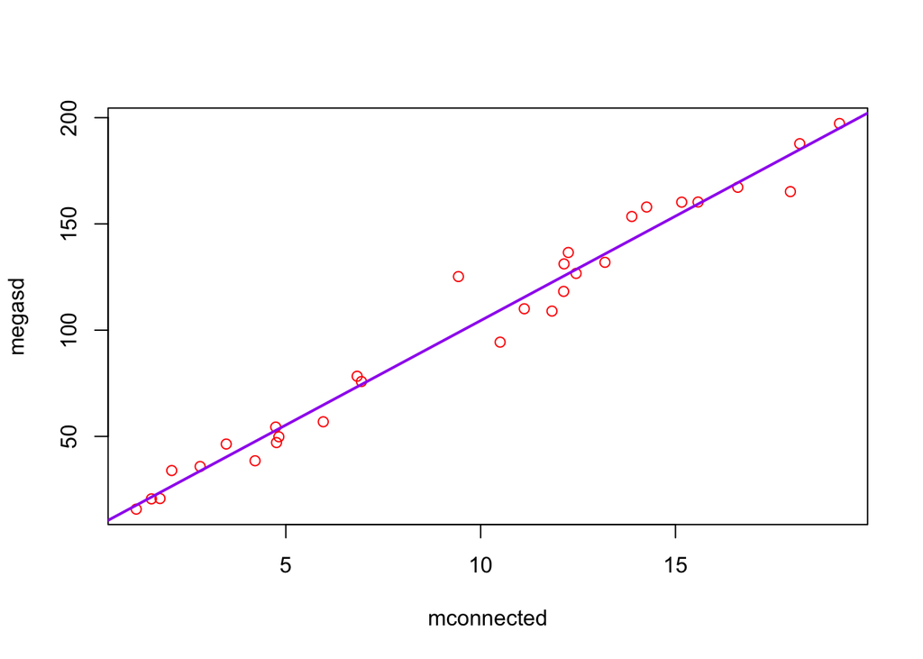

```r
plot(megasd~mconnected, data = URLADDRESS, col = "red")
mega.lm<-lm(megasd~mconnected, data = URLADDRESS)

#1b
abline(mega.lm, col = "purple", lwd = 2)
```

```r
#1c
vcov(mega.lm) #covariance matrix
```

```
##             (Intercept)  mconnected
## (Intercept)  10.8661271 -0.85425034
## mconnected   -0.8542503  0.08931002
```

```r
##################################
summary(mega.lm)
```

```
##
## Call:
## lm(formula = megasd ~ mconnected, data = URLADDRESS)
##
## Residuals:
##      Min       1Q   Median       3Q      Max
## -17.4601  -5.0653   0.0563   5.0002  26.3222
##
## Coefficients:
##             Estimate Std. Error t value Pr(>|t|)
## (Intercept)   6.1890     3.2964   1.878   0.0709 .
## mconnected    9.8313     0.2988  32.897   <2e-16 ***
## ---
## Signif. codes:  0 '***' 0.001 '**' 0.01 '*' 0.05 '.' 0.1 ' ' 1
##
## Residual standard error: 8.992 on 28 degrees of freedom
## Multiple R-squared:  0.9748, Adjusted R-squared:  0.9739
## F-statistic:  1082 on 1 and 28 DF,  p-value: < 2.2e-16
```

```r
##################################

# 1d
```

The standard error of Beta 1 is 0.2988

```r
#1e
vcov(mega.lm)[2,1]
```

```
## [1] -0.8542503
```

The covariance between Beta_not and Beta_1 is approximately -0.854 as shown in the variance-covariance matrix

```r
#1f.

#Construct 95% confidence interval

confint(mega.lm, level = 0.95)[2, 1:2]
```

```
##     2.5 %    97.5 %
##  9.219101 10.443425
```

```r
#1g.
summary(mega.lm)$adj.r.squared
```

```
## [1] 0.9738792
```

```r
summary(mega.lm)$adj.r.squared
```

```
## [1] 0.9738792
```

R-squared is 0.9748 while R-squared alpha is approximately 0.9739

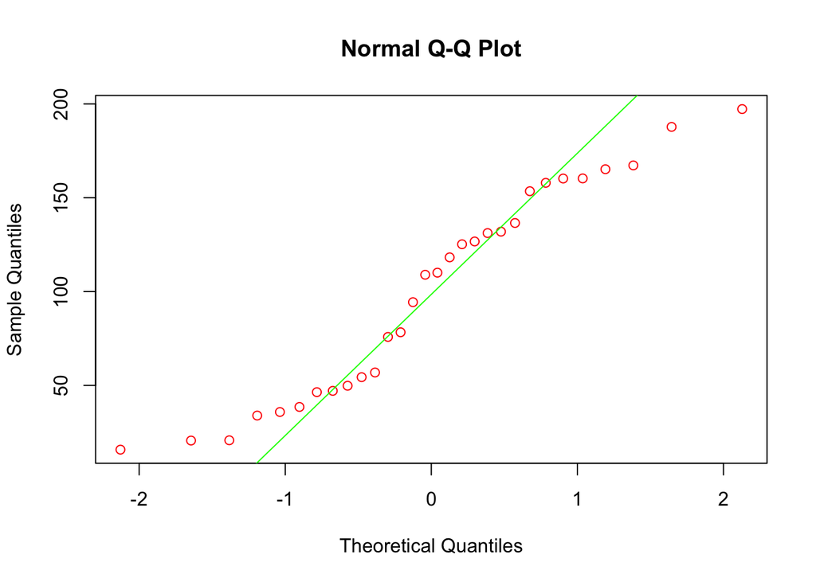

```r
#1h
qqnorm(URLADDRESS$megasd, col = "red")
qqline(URLADDRESS$megasd, col = "green")
```

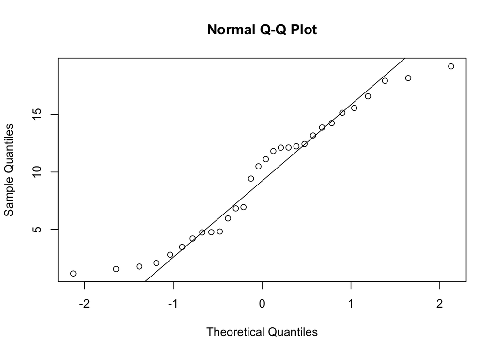

```r
qqnorm(URLADDRESS$mconnected)
qqline(URLADDRESS$mconnected)
```

```r
#1i

outlierTest(mega.lm)
```

```
##    rstudent unadjusted p-value Bonferroni p
## 13 3.536669          0.0014863      0.04459
```

```r
which.max(abs(rstudent(mega.lm)))
```

```
## 13
## 13
```

The data on row 13 is an outlier as show in the outlier test

```r
#1j
hat<-hatvalues(mega.lm)
hatCV<-2*2/30
sum(hat > hatCV)
```

```
## [1] 1
```

```r
which(hat > hatCV)
```

```
## 16
## 16
```

```r
DFFITS<-dffits(mega.lm)
dffitsCV <- 2*sqrt(2/30)
sum(DFFITS > dffitsCV)
```

```
## [1] 1
```

```r
which(DFFITS > dffitsCV)
```

```
## 13
## 13
```

Observation 13 has a DFFITS value greater than 2*sqrt(p/n)

```r
DFBETAS<-dfbetas(mega.lm)
dfbetasCV<- 2/sqrt(30)
sum(DFBETAS > dfbetasCV)
```

```
## [1] 0
```

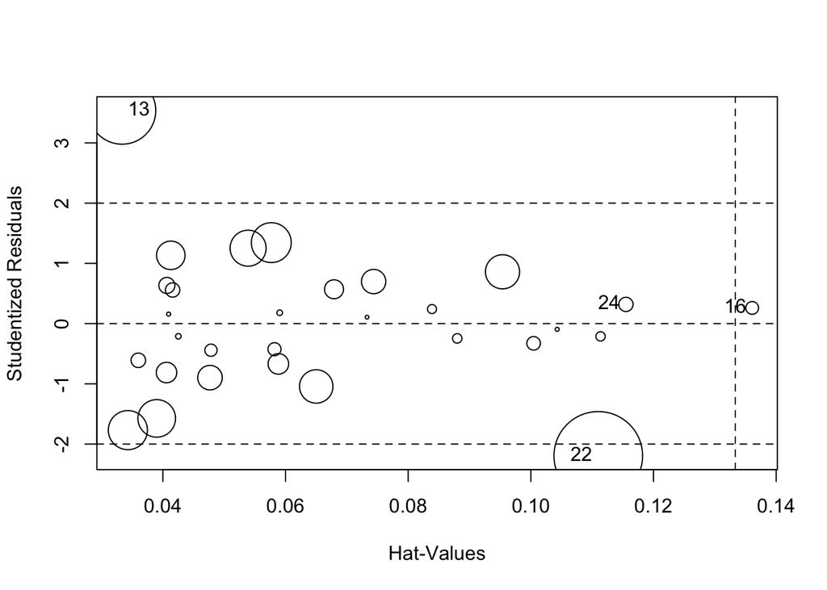

```
##       StudRes        Hat       CookD
## 13  3.5366686 0.03335346 0.152934227
## 16  0.2602743 0.13608497 0.005519218
## 22 -2.1953572 0.11099209 0.264746480
## 24  0.3188010 0.11550129 0.006855854
```

```r
influencePlot(mega.lm)
```

```r
#1k
predict(mega.lm, newdata = data.frame(mconnected = 5))
```

```
##        1
## 55.34529
```

```r
predict(mega.lm, newdata = data.frame(mconnected = 10))
```

```
##        1
## 104.5016
```

```r
predict(mega.lm, newdata = data.frame(mconnected = 15))
```

```
##        1
## 153.6579
```

**The mean value of megabytes downloaded by clients spending 5, 10, and 15 minutes on line are 55.34529, 104.5016 and 153.6579 respectively**

```r
predict(mega.lm, newdata = data.frame(mconnected = 5), interval = "conf", level = 0.90)
```

```
##        fit      lwr      upr
## 1 55.34529 51.71411 58.97646
```

```r
predict(mega.lm, newdata = data.frame(mconnected = 10), interval = "conf", level = 0.95)
```

```
##        fit      lwr     upr
## 1 104.5016 101.1282 107.875
```

```r
predict(mega.lm, newdata = data.frame(mconnected = 15), interval = "conf", level = 0.95)
```

```
##        fit      lwr      upr
## 1 153.6579 148.9273 158.3885
```

```r
#1l
predict(mega.lm, newdata = data.frame(mconnected = 30))
```

```
##        1
## 301.1269
```

```r
predict(mega.lm, newdata = data.frame(mconnected = 30), interval = "pred", level = 0.95)
```

```
##        fit      lwr      upr
## 1 301.1269 278.6086 323.6451
```

# #2

[figure not shown]

```r
#2a
plot(lostrevenue~numbersick, data = LOSTR, col = "purple")

#2b
linearModel<-lm(lostrevenue~numbersick, data = LOSTR)
abline(linearModel, col = "999900", lwd = 2)
```

```r
linearModel
```

```
##
## Call:
## lm(formula = lostrevenue ~ numbersick, data = LOSTR)
##
## Coefficients:
## (Intercept)   numbersick
##       294.8         96.9
```

```r
#2c
covMatrix<-vcov(linearModel)
covMatrix
```

```
##             (Intercept) numbersick
## (Intercept)  12724.0361 -741.70261
## numbersick    -741.7026   53.28323
```

```r
summary(linearModel) #this is just to print all the values needed
```

```
##
## Call:
## lm(formula = lostrevenue ~ numbersick, data = LOSTR)
##
## Residuals:
##     Min      1Q  Median      3Q     Max
## -104.57  -73.23  -52.03  -18.19 1139.29
##
## Coefficients:
##             Estimate Std. Error t value Pr(>|t|)
## (Intercept)    294.8      112.8   2.614   0.0155 *
## numbersick      96.9        7.3  13.274 2.87e-12 ***
## ---
## Signif. codes:  0 '***' 0.001 '**' 0.01 '*' 0.05 '.' 0.1 ' ' 1
##
## Residual standard error: 244.9 on 23 degrees of freedom
## Multiple R-squared:  0.8845, Adjusted R-squared:  0.8795
## F-statistic: 176.2 on 1 and 23 DF,  p-value: 2.874e-12
```

```r
#2d
confint(linearModel, level = 0.95)[2, 1:2]
```

```
##     2.5 %    97.5 %
##  81.79671 111.99720
```

```r
#2e

summary(linearModel)$r.squared
```

```
## [1] 0.8845437
```

```r
summary(linearModel)$adj.r.squared
```

```
## [1] 0.8795239
```

```r
#2f
which.max(abs(rstudent(linearModel))) #this prints the row with the outlier
```

```
## 4
## 4
```

```r
outlierTest(linearModel)
```

```
##   rstudent unadjusted p-value Bonferroni p
## 4 42.11082         1.5825e-22   3.9562e-21
```

The data in row 4 is an outlier, hence it is deleted to answer the remaining questions

```r
newLinearModel<-lm(lostrevenue~numbersick, data = LOSTR[-c(4),]) #compute linear model with row 4 deleted


#2g

predict(newLinearModel, newdata = data.frame(numbersick = 5))
```

```
##        1
## 703.8017
```

```r
predict(newLinearModel, newdata = data.frame(numbersick = 15))
```

```
##        1
## 1703.796
```

```r
predict(newLinearModel, newdata = data.frame(numbersick = 25))
```

```
##        1
## 2703.791
```

**The estimated lost revenue when 5, 15, and 25 employees are out sick are 703.8017, 1703.796, and 2703.791, respectively.**

```r
#2h
predict(newLinearModel, newdata = data.frame(numbersick = 14), interval = "pred", level = 0.95)
```

```
##        fit      lwr      upr
## 1 1603.797 1545.119 1662.474
```

# #3

```r
xi<-581
xi_sq<-28507
xi_yi<-2630
yi<-53
yi_sq<-267
n<-12
SSE<-22.08
Beta_1<-(xi_yi-(xi*yi/n))/(xi_sq - ((xi^2)/n))
Beta_1
```

```
## [1] 0.1695777
```

```r
SST<-(yi_sq)-((yi^2)/n)
SSR<-SST - SSE
df_error<-n-2
df_reg<-1
MSR<-SSR/df_reg
MSE<-SSE/df_error
F_obs<-MSR/MSE
p_value<-pf(4.91, 1, 10, lower.tail = F)
Y_bar<-yi/n
X_bar<-xi/n
beta_not<-Y_bar - (Beta_1*X_bar)

#complete anova table
```

```
##            df      SSE      MSE     Fobs     P-val
## Regression  1 10.83667 10.83667 4.907911 0.0510521
## Error      10 22.08000  2.20800       NA        NA
```

```
## The regression model is not statistically significant because the p-value is greater than
##     our significance level of 0.05. Hence there is no linear relationship between beta not and beta 1
```

```r
#3c
R.squared<-SSR/SST
R.squared
```

```
## [1] 0.3292152
```

```
## Our R-squared value indicates that 32.92% of the data fit the regression model, which is low.
```

```
## Our residual variance is 2.208 which is also the mean squared error
```

```
## The fitted regression line is Yhat =  0.1695777 x -3.793721
```

```r
#90% confidence interval
t_val<-qt(0.95, 10)
sumVal<-SSR/(Beta_1^2) #sumVal is the summation of x_i minus x_squared
SE<-sqrt(MSE/sumVal) #standard error of the slope
conF.int<-c(Beta_1 - t_val*SE, Beta_1 + t_val*SE)
conF.int
```

```
## [1] 0.03084172 0.30831371
```

# #4

```
##           df Sum Sq Mean Sq F value        P(>F)
## x1         1 3797.0  3797.0  283.56 3.288061e-10
## x2         1 1331.3  1331.3   99.35 1.868591e-07
## Residuals 13  174.1    13.4      NA           NA
```

```
## The regression sum of squares is 5128.3
```

```
## The model's error variance is 13.4
```

```
## R-Squared =  0.9671658
```

[output not shown]

```r
#4e
betaNot = -8.355
beta1 = 3.243
beta2 = -1.711
varBetaNot = 292.280
varBeta1 = 0.051
varBeta2 = 0.029
tNot<-(betaNot - 0)/sqrt(varBetaNot)
t1<-(beta1 - 3)/sqrt(varBeta1)
t2<-(beta2 +1)/sqrt(varBeta2)
pt(tNot, 13)*2 #p-value for betaNot
```

```
## [1] 0.6331913
```

```r
pt(t1, 13, lower.tail = F) #p-value for beta1
```

```
## [1] 0.150741
```

```r
pt(t2, 13) #p-value for beta2
```

```
## [1] 0.0005444476
```

```
## Since our p-value for BetaNot is greater than alpha = 0.05, we fail to reject the null hypothesis. Hence, beta_not = 0
```

```
## Since our p-value for Beta_1 is greater than alpha = 0.05, we fail to reject the null hypothesis. Hence, beta_1 = 3
```

```
## Since our p-value for Beta_2 is less than alpha = 0.05, we reject the null hypothesis that beta_2 = -1
```